# Session 2 · From tidy data to insight

## 2.2 · The superhost question

Do superhosts charge more — or are they just *placed* better?

We need medians *per zone and superhost status*:

- `group_by()` takes **two** columns — one mini-table per combination (3 zones × 2 statuses = 6);
- `fill` — the “colour inside” aesthetic of bars: mapped to `host_is_superhost`, each zone gets a pair of bars;
- `position = "dodge"` — place the pair side by side. The other options: `"stack"` (the default: bars pile on top of each other — good for totals), `"fill"` (stack, then stretch every bar to full height — shows shares instead of values), `"identity"` (each bar drawn at its own value, overlapping — for bars, almost never what you want).

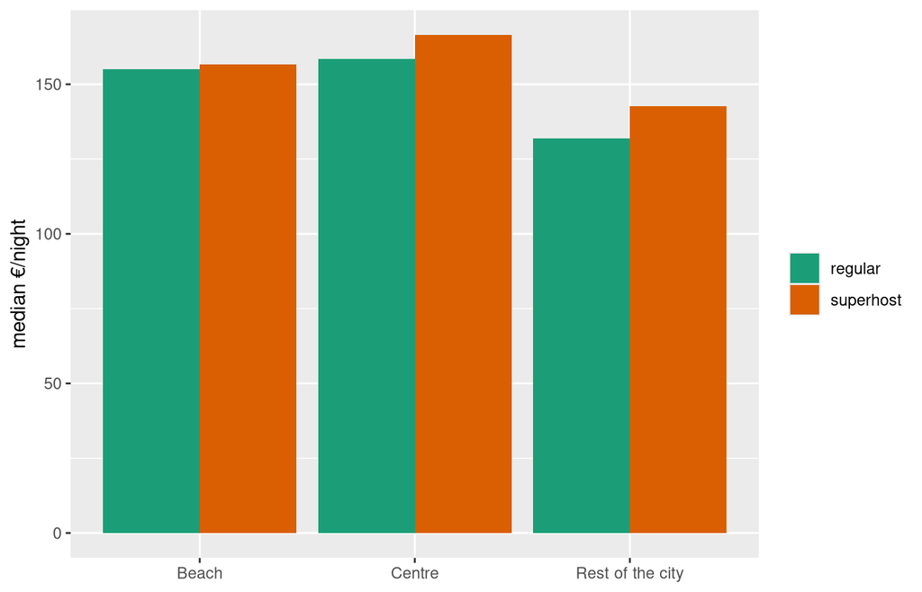

```r
listings |>
  filter(!is.na(price_eur), !is.na(host_is_superhost), price_eur < 1000) |>
  group_by(zone, host_is_superhost) |>
  summarise(median_price = median(price_eur), n = n(), .groups = "drop") |>
  ggplot() +
  aes(x = zone, y = median_price, fill = host_is_superhost) +
  geom_col(position = "dodge") +
  scale_fill_brewer(palette = "Dark2", labels = c("regular", "superhost"), na.translate = FALSE) +
  labs(fill = NULL, x = NULL, y = "median €/night")
```

New scale, same logic — *categorical* colour/fill:

- `scale_fill_brewer(palette = "Dark2")` — a ready-made [ColorBrewer](https://colorbrewer2.org) palette (`"Set2"`, `"Paired"`…): designed for distinguishability, most are colour-blind-safe;
- `na.translate = FALSE` — keep the NA level out of the legend;
- to set exact colours yourself: `scale_fill_manual(values = c("regular" = "grey65", "superhost" = "#2c7fb8"))` — likewise `scale_colour_manual()`.

Why split by zone? Because superhosts might simply be located in expensive areas — one overall comparison would mix “superhosts charge more” with “superhosts are in pricier zones”. Comparing inside each zone removes (roughly) the location effect: the gap that remains within a zone is not explained by where the listing is. Block 3 does this properly, controlling for every variable at once.

## 2.3 · Reviews over time

Each review has a date, so counting reviews per month shows the platform’s activity over time:

- `floor_date(date, "month")` — round every date down to the first day of its month;
- `count(month)` — tally each month;
- `geom_line()` — connect the months in order:

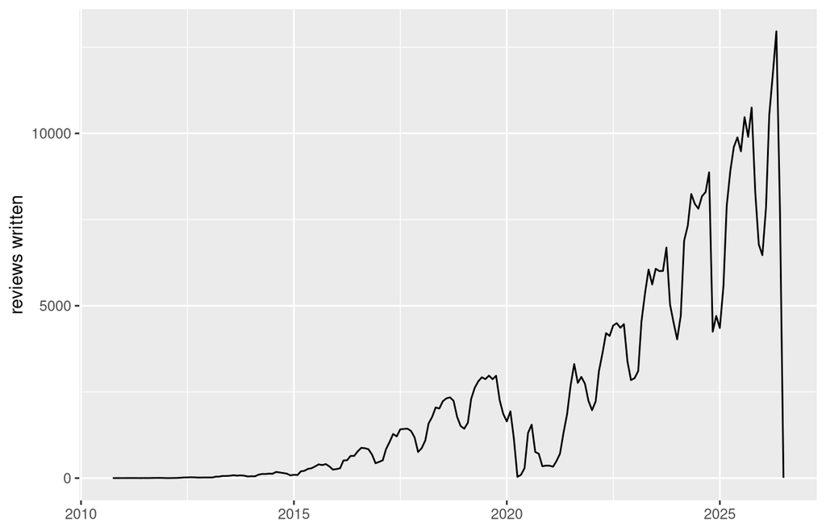

```r
reviews <- read_csv("data/reviews.csv.gz", show_col_types = FALSE) |>
  # Session 1's lesson: in some snapshots the date arrives as "12/10/2010" text
  mutate(date = if (is.character(date)) dmy(date) else date)

reviews |>
  count(month = floor_date(date, "month")) |>
  ggplot() +
  aes(x = month, y = n) +
  geom_line() +
  labs(y = "reviews written", x = NULL)
```

Each review marks a stay, so the curve traces the market’s growth. Find the COVID crater and the recovery.

🧰 **Sprint toolbox**:

| Function | What it does |
| --- | --- |
| `aes(colour = group)` + `geom_line()` | one line per group value, each its own colour — the legend appears by itself |
| `linewidth =` | line thickness (lines use `linewidth`, points use `size`) |
| `scale_colour_brewer(palette = "Dark2")` | colour-blind-friendly palette for categories (fill version: `scale_fill_brewer()`, seen in 2.2) |
| `scale_x_continuous(labels = label_percent())` | format axis ticks as percentages — siblings: `label_dollar(prefix = "€")`, `label_comma()` (package **scales**) |
| `left_join(df, join_by(a == b))` | Session 1’s join — here to attach each listing’s `zone` to `calendar_monthly` |

- 1. Does the **Beach** fill up more sharply in summer than the **Centre**? (join `calendar_monthly` to listings’ `zone`, then month × zone)
- 2. Which districts are most dominated by **entire homes**?
- 3. Do **higher-rated** listings charge more? (rating vs price, and beware the rating pile-up)
- 4. Do **veteran listings** (`listing_age_yrs`) hold better ratings than recent ones?
- 5. Where do **long-stay** listings (`long_stay`) live — Centre or periphery?

```r
# Your code here
```

# EXTRA · Block 3 · A first model: what drives the price? ⏱ 40′

EDA showed price moves with capacity, room type, zone… **all at once**. A linear model holds everything constant at the same time.

**`lm()` in one slide.** `lm(y ~ x1 + x2, data = df)` fits a *linear regression*:

- it finds the coefficients of `y ≈ b0 + b1·x1 + b2·x2` that minimize the squared errors across all rows;
- the first argument is a **formula**: `~` reads “explained by”, `+` adds predictors;
- a categorical column (like `room_type`) expands automatically into one yes/no indicator per level, each measured *against a baseline level*;
- inference, assumptions, diagnostics → your statistics course. Today: fit, read, stay honest.

We model `log(price_eur)` rather than raw price: 1.2 showed prices are log-normal, and log coefficients can be read as *percentages* (below).

First, the **model frame** — the subset the model sees, each filter deliberate:

- known price only;
- under €1,000 — a few extreme prices would drag the whole fit;
- the two room types that make an apples-to-apples comparison;
- `drop_na()` on every predictor: `lm()` would drop incomplete rows silently anyway — better to do it ourselves and *know it*:

```r
model_frame <- listings |>
  filter(!is.na(price_eur), price_eur < 1000,
         room_type %in% c("Entire home/apt", "Private room")) |>
  drop_na(accommodates, baths, review_scores_rating)

m1 <- lm(log(price_eur) ~ accommodates + baths + room_type + zone +
           review_scores_rating,
         data = model_frame)

tidy(m1)
```

```
## # A tibble: 7 × 5
##   term                  estimate std.error statistic   p.value
##   <chr>                    <dbl>     <dbl>     <dbl>     <dbl>
## 1 (Intercept)             4.31     0.0628      68.6  0
## 2 accommodates            0.131    0.00379     34.7  9.48e-242
## 3 baths                   0.0232   0.0108       2.16 3.07e-  2
## 4 room_typePrivate room  -0.664    0.0161     -41.3  0
## 5 zoneCentre              0.0648   0.0133       4.87 1.12e-  6
## 6 zoneRest of the city   -0.122    0.0133      -9.16 6.93e- 20
## 7 review_scores_rating    0.0599   0.0128       4.69 2.73e-  6
```

`tidy(m1)` (package **broom**) returns the model as a tibble, one row per coefficient:

- `estimate` — the fitted number; `std.error` — its uncertainty;
- `statistic` / `p.value` — is the effect distinguishable from zero, given the noise? (read lightly today; the full story is stats-course material);
- note `room_type` became `room_typePrivate room`: a yes/no indicator against the baseline level (entire homes), which lives inside the intercept.

**From estimates to percentages.** The estimates are in log-euros — exact but unreadable. Additive steps in log are multiplicative steps in €: a coefficient `b` multiplies the price by `exp(b)`, so `(exp(b) - 1) × 100` is the **percentage effect**. Put both side by side:

```r
tidy(m1) |>
  mutate(pct_effect = (exp(estimate) - 1) * 100) |>
  select(term, estimate, pct_effect)
```

```
## # A tibble: 7 × 3
##   term                  estimate pct_effect
##   <chr>                    <dbl>      <dbl>
## 1 (Intercept)             4.31      7326.
## 2 accommodates            0.131       14.0
## 3 baths                   0.0232       2.35
## 4 room_typePrivate room  -0.664      -48.5
## 5 zoneCentre              0.0648       6.69
## 6 zoneRest of the city   -0.122      -11.5
## 7 review_scores_rating    0.0599       6.17
```

Two rows by hand — note the asymmetry:

- `accommodates` ≈ 0.13 → `exp(0.13)` ≈ 1.14 → **+14% per guest**;
- `room_typePrivate room` ≈ −0.66 → `exp(−0.66)` ≈ 0.52 → **−48%** — *not* −66%!
- shortcut: for |b| < 0.1 (like `zoneCentre`) `estimate` and `pct_effect` nearly coincide — beyond that, do the `exp()`;
- ignore `pct_effect` on the intercept row: the intercept is the baseline log-price, not an effect.

How to state a coefficient (structure, not exact numbers): *“holding everything else fixed, each extra guest of capacity raises price by about X%”*; *“a private room costs about Y% less than an entire home, same size, same zone”*; *“the Centre premium survives all controls”*. Whatever `review_scores_rating` does — a lot, a little, nothing — report it with its size (Sprint 2’s question (c) previewed this).

```r
glance(m1) |> select(r.squared, nobs)
```

```
## # A tibble: 1 × 2
##   r.squared  nobs
##       <dbl> <int>
## 1     0.515  6414
```

- `nobs` — the rows the model *actually* used: compare with `nrow(listings)`; filters + `drop_na()` removed the rest. Always know how much data you modelled.
- `r.squared` — the share of the variance of `log(price)` explained, 0 to 1: here about half.

The third broom verb, `augment(m, data = df)`, returns your data with the model’s per-row columns attached:

- `.fitted` — the model’s prediction for that row: here a predicted *log*-price, so `exp(.fitted)` is the prediction in €;
- `.resid` — the residual, actual − fitted: positive = the listing charges more than the model expects, negative = less;
- one row per observation the model used, so you can filter, plot and rank predictions like any other table.

Now plot what the model predicts against what is real:

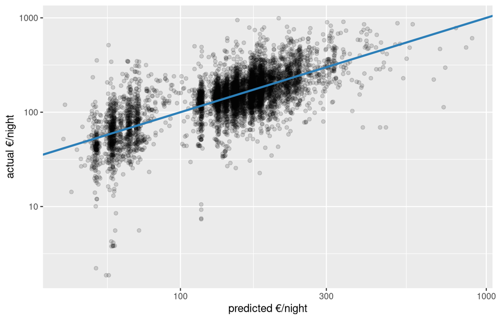

```r
augment(m1, data = model_frame) |>
  mutate(predicted_eur = exp(.fitted)) |>
  ggplot() +
  aes(x = predicted_eur, y = price_eur) +
  geom_point(alpha = 0.15) +
  geom_abline(colour = "#2c7fb8", linewidth = 1) +   # reference line: prediction = reality
  scale_x_log10() + scale_y_log10() +
  labs(x = "predicted €/night", y = "actual €/night")
```

(`geom_abline()` draws a reference line — by default slope 1, intercept 0: the 45° diagonal where prediction = reality.) How to read the cloud:

- the cloud tracks the diagonal — the model captures something real;
- at any predicted price there is wide vertical spread: identical-looking flats charging quite different rates;
- that spread **is** the missing half of R²: photos, terrace, decor, host skill — everything our table can’t see;
- in the report: *“size, type and location explain about half of the price variation”*. R² of 0.3–0.6 is normal for prices.

## The bargain detector

A strongly **negative** `.resid` is a listing *cheaper than the model thinks it should be* — exactly what our client wants to browse:

```r
bargains <- augment(m1, data = model_frame) |>
  filter(is_active, number_of_reviews >= 10) |>      # real, live listings only
  slice_min(.resid, n = 10) |>
  mutate(expected_eur = exp(.fitted)) |>
  select(name, neighbourhood_cleansed, room_type,
         price_eur, expected_eur, review_scores_rating)
bargains
```

```
## # A tibble: 10 × 6
##    name                  neighbourhood_cleansed room_type price_eur expected_eur
##    <chr>                 <chr>                  <chr>         <dbl>        <dbl>
##  1 Estudio 2 germans     BENIMACLET             Private …       8.5         61.5
##  2 apartament beach 3 r… LA MALVA-ROSA          Entire h…      34.8        199.
##  3 City Center Loft P2   EL MERCAT              Entire h…      33.1        137.
##  4 City Center loft 1C   LA SEU                 Entire h…      34.3        139.
##  5 Monumental Loft 1E    LA SEU                 Entire h…      34.3        139.
##  6 Comfort Central Loft… LA SEU                 Entire h…      34.8        140.
##  7 Central Market Loft … EL MERCAT              Entire h…      34.3        138.
##  8 Loft Lonja de la Sed… LA SEU                 Entire h…      34.3        137.
##  9 ★Valencia City Cente… EL CARME               Entire h…      36.2        137.
## 10 Acogedora habitación… ELS ORRIOLS            Private …      14.0         52.5
## # ℹ 1 more variable: review_scores_rating <dbl>
```

Two caveats: the model can’t see photos or renovation quality (cheap may be cheap *for a reason*), and `exp(.fitted)` is an approximate back-transform. This is a shortlist to visit, not to buy.

*Stretch — a first classifier.* When the outcome is yes/no instead of a number, use **`glm()`** (*generalized* linear models):

- same formula language, plus a `family` argument declaring the outcome type;
- `family = binomial` = **logistic regression**: it models the *probability* of TRUE;
- coefficients are in log-odds — for now read only **sign and significance**; positive = associated with being a superhost:

```r
m2 <- glm(host_is_superhost ~ review_scores_rating + number_of_reviews +
            calculated_host_listings_count,
          data = listings, family = binomial)
tidy(m2)   # read the *signs*: what goes with being a superhost?
```

```
## # A tibble: 4 × 5
##   term                            estimate std.error statistic   p.value
##   <chr>                              <dbl>     <dbl>     <dbl>     <dbl>
## 1 (Intercept)                    -19.2      0.763        -25.1 5.69e-139
## 2 review_scores_rating             3.91     0.158         24.7 3.08e-134
## 3 number_of_reviews                0.00439  0.000312      14.1 7.65e- 45
## 4 calculated_host_listings_count  -0.0230   0.00182      -12.7 8.16e- 37
```

🧰 **Sprint toolbox** — model-handling tools (all from **broom** except the first):

| Function | What it does |
| --- | --- |
| `update(m, . ~ . + new_var)` | refit an existing model with a tweaked formula: `. ~ .` means “same response, same predictors”, then `+`/`-` terms |
| `tidy(m)` | the coefficient table as a tibble (estimate, std.error, p.value) |
| `glance(m)` | one-row model summary — `glance(m)$r.squared` picks out the fit |
| `augment(m, data = df)` | your data plus per-row model columns: `.fitted` (prediction) and `.resid` (actual − predicted) |
| `exp(x)` | undo the log: `exp(coef) - 1` ≈ the % effect; `exp(.fitted)` ≈ the predicted price in € |

**Sprint 3** ⏱ 15:00:

1. Add `long_stay` and `baths_shared` to `m1` as `m1b`. Does R² improve? Interpret ONE new coefficient in one plain-language sentence.
2. Re-run the bargain detector on **Centre** listings only. Would you send your client any of the top 5?

```r
# Your code here
```

# Block 4 · Wrap-up

- **Grammar of graphics** — every plot is data + `aes()` + geom; swap the geom, change the question. Scales replace silent defaults (`scale_x_log10`, viridis for continuous colour, brewer for categories, `label_percent()` on axes); order categories with `fct_reorder`/`fct_lump_n`; `facet_wrap`/`facet_grid` for small multiples.
- **The EDA loop** — question → transform → plot → repeat; `group_by()` with two columns; two measures = two stacked plots (patchwork), **never two y-axes**; read data critically (the booking-horizon caveat, silent NA lines after joins).
- **The model** — `lm(log(price) ~ ...)`; read it with broom: `tidy` (coefficients: `exp(b) − 1` = % effect), `glance` (`nobs`, `r.squared`, `sigma`), `augment` (`.fitted`, `.resid` → the bargain detector); `glm(family = binomial)` for yes/no outcomes.